# Individual Analysis

```r
cor(cacaoMeans$Rating, cacaoMeans$Cocoa_Percent)
```

```
## [1] -0.1784699
```

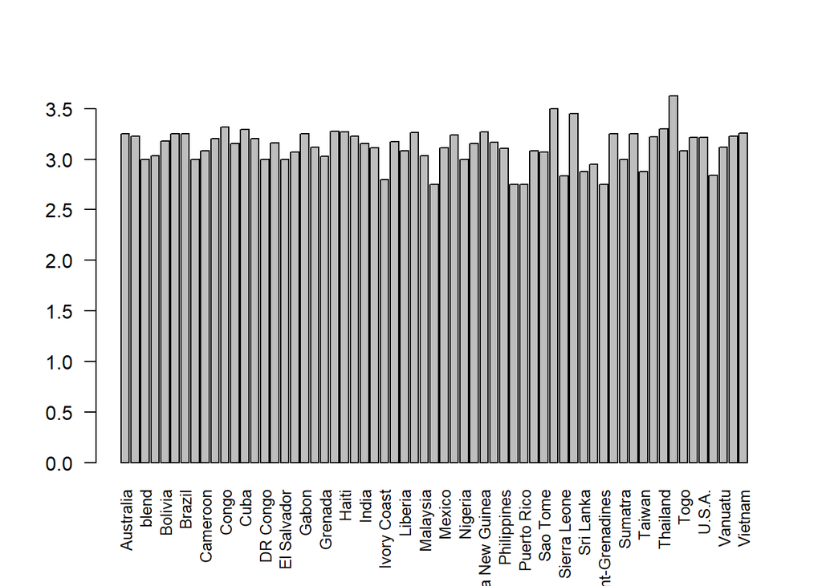

```r
originRatings <- choco[c("Bean_Origin", "Rating")]
originMeans <- aggregate(Rating ~ Bean_Origin, originRatings, mean)
originMeansV <- setNames(originMeans$Rating, originMeans$Bean_Origin)
barplot(originMeansV, las=2, cex.names=0.8)
```

```r
head(originMeans[order(originMeans$Rating), ])
```

```
##              Bean_Origin   Rating
## 32            Martinique 2.750000
## 40              Principe 2.750000
## 41           Puerto Rico 2.750000
## 49 St.Vincent-Grenadines 2.750000
## 27           Ivory Coast 2.800000
## 45          Sierra Leone 2.833333
```

```r
head(originMeans[order(-originMeans$Rating), ])
```

```
##            Bean_Origin   Rating
## 56              Tobago 3.625000
## 44 Sao Tome & Principe 3.500000
## 46     Solomon Islands 3.450000
## 11               Congo 3.318182
## 55            Thailand 3.300000
## 13                Cuba 3.291667
```

There doesn’t seem to be a lot of variation in the ratings of beans, as seen in the barplot. Many of the countries from which the highest and lowest rated beans were in the Caribbean and near Africa according to the sorted data frame. However, two countries that produce some of the highest rated beans, Thailand and the Solomon Islands, break this trend since they are located in Asia and Oceania.

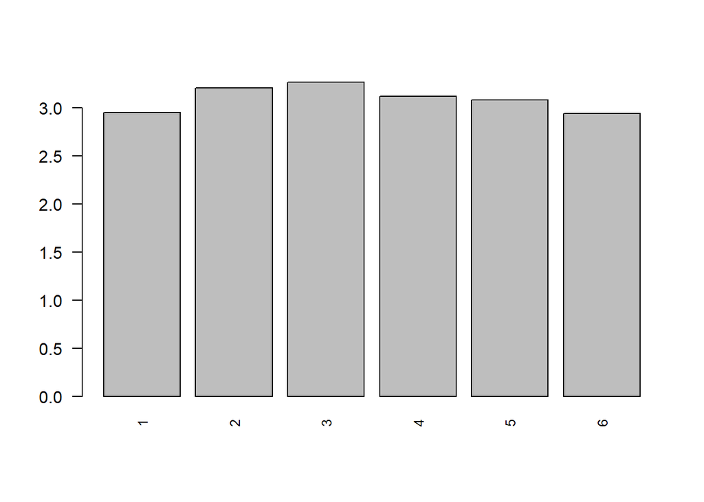

```r
numIngredientsRatings <- choco[c("Ingredients", "Rating")]
numIngredientsRatings$Num_Ingredients <- with(numIngredientsRatings, as.numeric(substr(Ingredients, 1, 1)))
numIngredientsRatings <- numIngredientsRatings[,c("Num_Ingredients", "Rating")]
numMeans <- aggregate(Rating ~ Num_Ingredients, numIngredientsRatings, mean)
numMeansV <- setNames(numMeans$Rating, numMeans$Num_Ingredients)
barplot(numMeansV, las=2, cex.names=0.8)
```

```r
cor(numMeans$Rating, numMeans$Num_Ingredients, method="spearman")
```

```
## [1] -0.3714286
```

I decided to analyze the data to see if the number of ingredients has an effect on the rating a chocolate bar receives. The bar plot shows us that chocolate containing 2 or 3 ingredients has the highest average rating, with 3 being the best. More or less ingredients negatively impacts the score. The correlation between the rating and the number of ingredients seems to support this, as the correlation was -0.37 which suggests a moderate correlation between the two variables.

```r
allMean <- mean(choco$Rating)
vanilly <- choco[c("Ingredients", "Rating")]
vanillaRatings <- filter(vanilly, grepl("V", Ingredients))
nonVanillaRatings <- filter(vanilly, !grepl("V", Ingredients))
vanillaMean <- mean(vanillaRatings$Rating)
nonVanillaMean <- mean(nonVanillaRatings$Rating)
vanillaTest <- c(allMean, vanillaMean, nonVanillaMean)
names(vanillaTest) <- c("All Chocolate", "Chocolate With Vanilla", "Chocolate Without Vanilla")
vanillaTest
```

```
##             All Chocolate    Chocolate With Vanilla Chocolate Without Vanilla
##                  3.184083                  3.032328                  3.210973
```

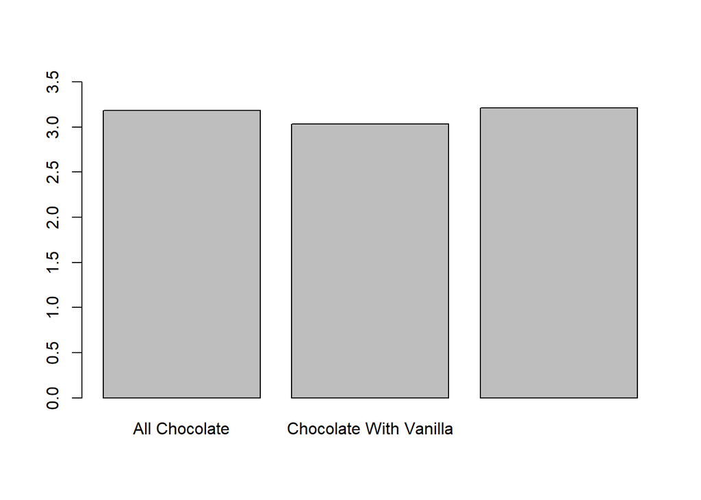

```r
barplot(vanillaTest, ylim=c(0,3.5))
```